# Lab#5

Lab 5 Higgs Classification

In tihs report, we will be working with an inclusive search for the standard model Higgs boson in pp collisions at √ s = 13 TeV at the LHC using simulated data. Our goal is to find the optimal event selections to enhance the discovery sensitivity by using our datasets, and the best event selections will be applied to a selected pseudo-experiment data.

What is LHC?

The Large Hadron Collider (LHC) is the world’s largest and most powerful particle accelerator. It consists of a 27-kilometre ring of superconducting magnets with a number of accelerating structures to boost the energy of the particles along the way. Two high-energy particle beams travel inside the accelerator towards opposite directions at close to the speed of light before they are made to collide at four different points. The aim of the LHC's detectors is to allow physicists to test the predictions of different theories of particle physics, including measuring the properties of the Higgs boson and searching for the large family of new particles predicted by supersymmetric theories, as well as other unsolved questions of physics.

Here is the working process of LHC:

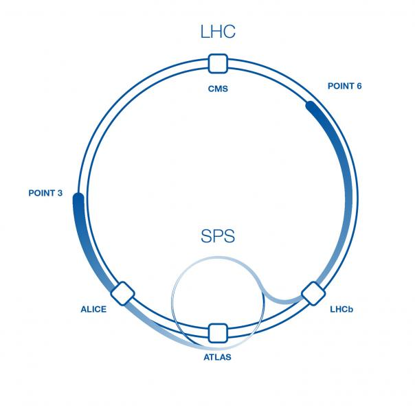

Features

Exploring the Datasets

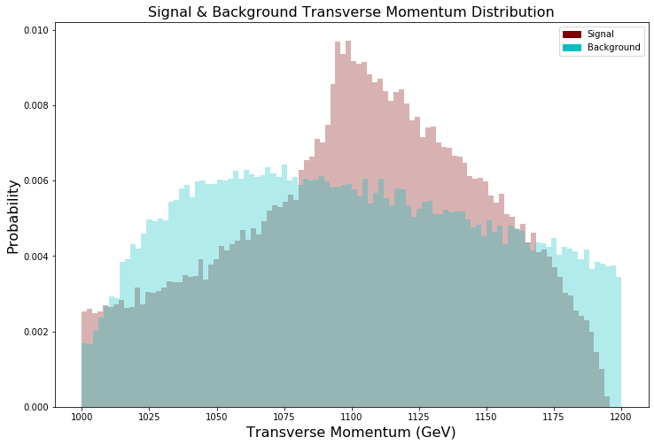

```python
import pickle
%matplotlib inline
import numpy as np
import matplotlib
import matplotlib.pyplot as plt
import matplotlib.patches as mpatches
from scipy import stats

# open the file of interest, and use pickle loading
infile = open ("higgs_100000_pt_1000_1200.pkl",'rb')
higgs = pickle.load(infile)

infile2 = open ("qcd_100000_pt_1000_1200.pkl",'rb')
qcd = pickle.load(infile2)

plt.rcParams["figure.figsize"] = (12, 8)

plt.hist(higgs['pt'][:], 100, color = 'maroon', density=True, alpha=0.3)
plt.hist(qcd['pt'][:], 100, color = 'c', density=True, alpha=0.3)
plt.xlabel('Transverse Momentum (GeV)', fontsize=16)
plt.ylabel('Probability', fontsize=16)
plt.title('Signal & Background Transverse Momentum Distribution', fontsize=16)
maroon_patch = mpatches.Patch(color='maroon', label='Signal')
c_patch = mpatches.Patch(color='c', label='Background')
plt.legend(handles=[maroon_patch, c_patch])
```

The above graph is the distribution of Transverse Momentum (pT) of both signal data and background data. The signal data are having a much greater probability in the range from 1080 GeV to 1120 GeV than out of this range. In contrast, the background data distribution showed an increasing probability around 1050 GeV. Also, compared with the right-skewed background distribution, the signal data are more skewed to the left. The difference between the distributions of background and signal data proves to have discrimination power.

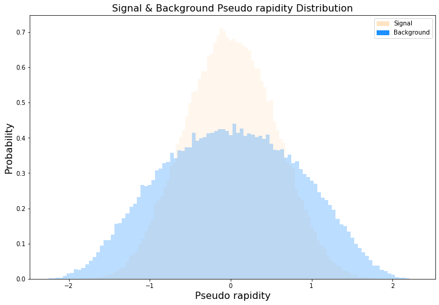

```python
plt.hist(higgs['eta'][:], 100, color = 'bisque', density=True, alpha=0.3)
plt.hist(qcd['eta'][:], 100, color = 'dodgerblue', density=True, alpha=0.3)
plt.xlabel('Pseudo rapidity', fontsize=16)
plt.ylabel('Probability', fontsize=16)
plt.title('Signal & Background Pseudo rapidity Distribution', fontsize=16)
sig_patch = mpatches.Patch(color='bisque', label='Signal')
bcg_patch = mpatches.Patch(color='dodgerblue', label='Background')
plt.legend(handles=[sig_patch, bcg_patch])
```

The above histogram is the distribution of both the signal and background of Pseudo rapidity. As we can see, they both fall into a normal distribution with a mean around 0. The discrimination power of Pseudo rapidity is not great as it of Transverse momentum, but the range of background data is larger than the signal's range, and their peak value can also help us to distinguish the signal from background.

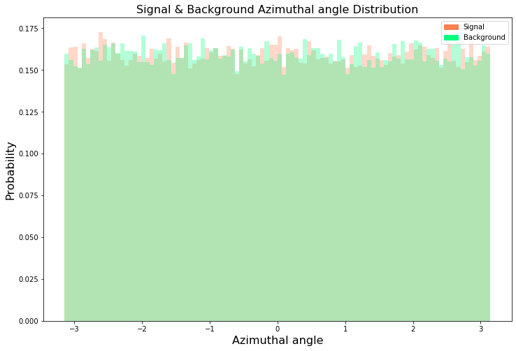

```python
plt.hist(higgs['phi'][:], 100, color = 'coral', density=True, alpha=0.3)
plt.hist(qcd['phi'][:], 100, color = 'springgreen', density=True, alpha=0.3)
plt.xlabel('Azimuthal angle', fontsize=16)
plt.ylabel('Probability', fontsize=16)
plt.title('Signal & Background Azimuthal angle Distribution', fontsize=16)
sig_patch = mpatches.Patch(color='coral', label='Signal')
bcg_patch = mpatches.Patch(color='springgreen', label='Background')
plt.legend(handles=[sig_patch, bcg_patch])
```

This histogram shows the distributions of background and signal data for the azimuthal angle. It is the angle measurement in X-Y plane. From above graph, we cannot tell a clear difference bwteen each data distribution. They are both randomly distributed with no unique property. Therefore, it shows no discrimination power between signal and background.

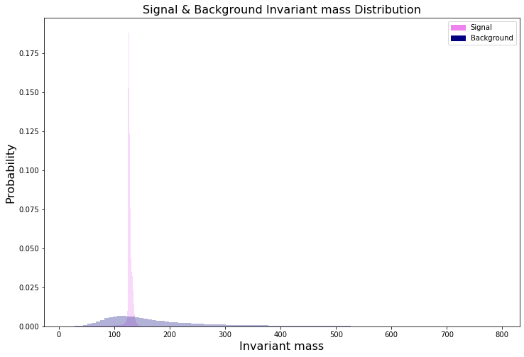

```python
plt.hist(higgs['mass'][:], 100, color = 'violet', density=True, alpha=0.3)
plt.hist(qcd['mass'][:], 100, color = 'navy', density=True, alpha=0.3)
plt.xlabel('Invariant mass', fontsize=16)
plt.ylabel('Probability', fontsize=16)
plt.title('Signal & Background Invariant mass Distribution', fontsize=16)
sig_patch = mpatches.Patch(color='violet', label='Signal')
bcg_patch = mpatches.Patch(color='navy', label='Background')
plt.legend(handles=[sig_patch, bcg_patch])
```

The graph above is the histogram of distributions of background and signal data of invariant mass. From the graph, we can see that the signal distribution of the mass has a significat spike around the range from 125 to 140. Different from the signal, the background distribution has a more normal shape and skewed to the right. We can clearly distinguish between the signal and background. Therefore, The invariant mass provides a discrimination power.

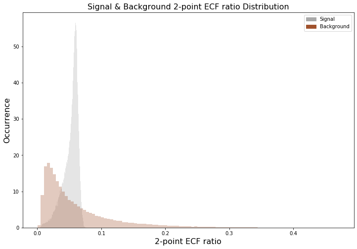

```python
plt.hist(higgs['ee2'][:], 100, color = 'darkgray', density=True, alpha=0.3)
plt.hist(qcd['ee2'][:], 100, color = 'sienna', density=True, alpha=0.3)
plt.xlabel('2-point ECF ratio', fontsize=16)
plt.ylabel('Occurrence', fontsize=16)
plt.title('Signal & Background 2-point ECF ratio Distribution', fontsize=16)
sig_patch = mpatches.Patch(color='darkgray', label='Signal')
bcg_patch = mpatches.Patch(color='sienna', label='Background')
plt.legend(handles=[sig_patch, bcg_patch])
```

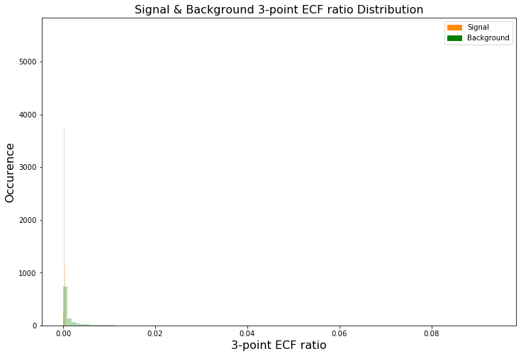

```python
plt.hist(higgs['ee3'][:], 100, color = 'darkorange', density=True, alpha=0.3)
plt.hist(qcd['ee3'][:], 100, color = 'green', density=True, alpha=0.3)
plt.xlabel('3-point ECF ratio', fontsize=16)
plt.ylabel('Occurence', fontsize=16)
plt.title('Signal & Background 3-point ECF ratio Distribution', fontsize=16)
sig_patch = mpatches.Patch(color='darkorange', label='Signal')
bcg_patch = mpatches.Patch(color='green', label='Background')
plt.legend(handles=[sig_patch, bcg_patch])
```

Above is the histogram of signal and background distribution of 3-point ECF ratio. From the above graph, we cannot actually get a good observation. We will plot them in two separate graphs to see more detailed distributions.

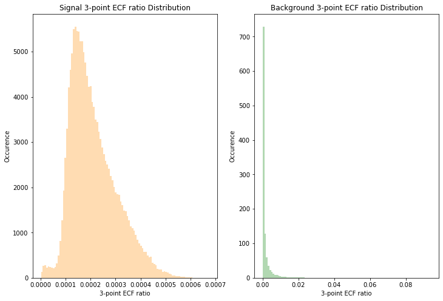

```python
fig, (ax1, ax2) = plt.subplots(1, 2)
ax1.hist(higgs['ee3'][:], 100, color = 'darkorange', density=True, alpha=0.3)
ax1.set_xlabel('3-point ECF ratio')
ax1.set_ylabel('Occurence')
ax1.set_title('Signal 3-point ECF ratio Distribution')

ax2.hist(qcd['ee3'][:], 100, color = 'green', density=True, alpha=0.3)
ax2.set_xlabel('3-point ECF ratio')
ax2.set_ylabel('Occurence')
ax2.set_title('Background 3-point ECF ratio Distribution')
```

As we can see from the graphs, the two distributions has similar shapes. They both are right-skewed with mean around the same value. However, the background has a larger range compared with the signal. There is a large overlap between the signal and background. Therefore, the discrimination pwower of the 3-point ECF ratio is not significant.

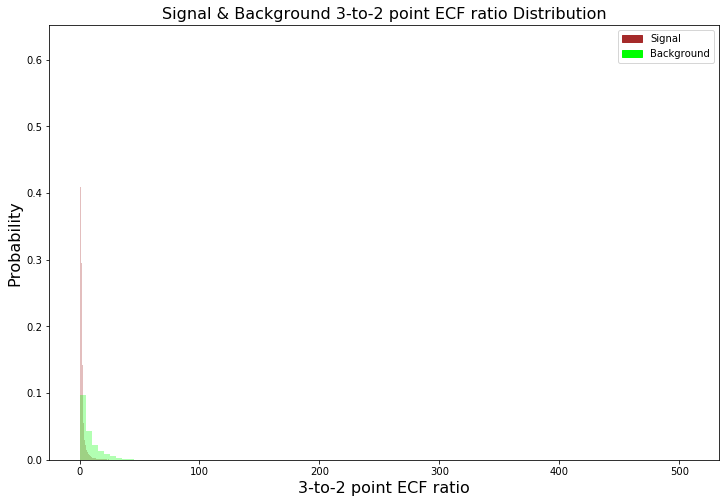

```python
plt.hist(higgs['d2'][:], 100, color = 'brown', density=True, alpha=0.3)
plt.hist(qcd['d2'][:], 100, color = 'lime', density=True, alpha=0.3)
plt.xlabel('3-to-2 point ECF ratio', fontsize=16)
plt.ylabel('Probability', fontsize=16)
plt.title('Signal & Background 3-to-2 point ECF ratio Distribution', fontsize=16)
sig_patch = mpatches.Patch(color='brown', label='Signal')
bcg_patch = mpatches.Patch(color='lime', label='Background')
plt.legend(handles=[sig_patch, bcg_patch])
```

In order to get an accurate observation, we will need to plot them separately.

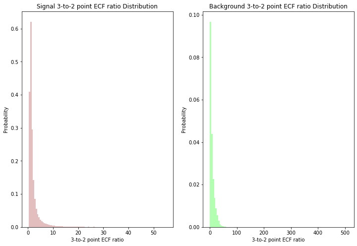

```python
fig, (ax1, ax2) = plt.subplots(1, 2)
ax1.hist(higgs['d2'][:], 100, color = 'brown', density=True, alpha=0.3)
ax1.set_xlabel('3-to-2 point ECF ratio')
ax1.set_ylabel('Probability')
ax1.set_title('Signal 3-to-2 point ECF ratio Distribution')

ax2.hist(qcd['d2'][:], 100, color = 'lime', density=True, alpha=0.3)
ax2.set_xlabel('3-to-2 point ECF ratio')
ax2.set_ylabel('Probability')
ax2.set_title('Background 3-to-2 point ECF ratio Distribution')
```

From the above two graphs, the signal and background distribution of 3-to-2 point ECF ratio has little difference other than the range of the data value. They are both right-skewed and have a large area of overlap which is similar to the 3-point ECF ratio. Therefore, it does not provide a discriminatio power bwteen signal and background.

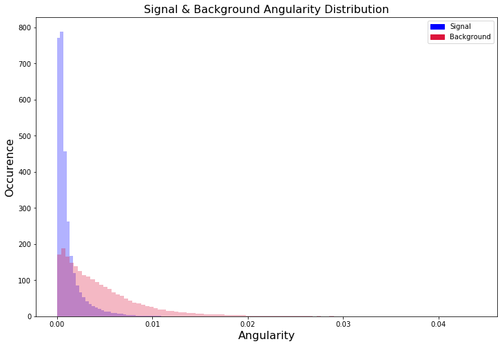

```python
plt.hist(higgs['angularity'][:], 100, color = 'b', density=True, alpha=0.3)
plt.hist(qcd['angularity'][:], 100, color = 'crimson', density=True, alpha=0.3)
plt.xlabel('Angularity', fontsize=16)
plt.ylabel('Occurence', fontsize=16)
plt.title('Signal & Background Angularity Distribution', fontsize=16)
sig_patch = mpatches.Patch(color='b', label='Signal')
bcg_patch = mpatches.Patch(color='crimson', label='Background')
plt.legend(handles=[sig_patch, bcg_patch])
```

The above graph is the distributions of signal and background Angularity. The signal data of angularity has a much bigger peak occurence than the background and it has a sharp decline as well. In contrast, the background angularity decreases more gradually. Even though their distribution shapes are both right-skewed, we can clearly distibguish the signal from background. Therefore, the angularity provides a discrimination power.

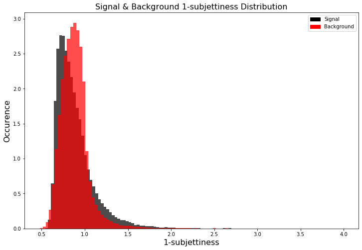

```python
plt.hist(higgs['t1'][:], 100, color = 'black', density=True, alpha=0.7)
plt.hist(qcd['t1'][:], 100, color = 'r', density=True, alpha=0.7)
plt.xlabel('1-subjettiness', fontsize=16)
plt.ylabel('Occurence', fontsize=16)
plt.title('Signal & Background 1-subjettiness Distribution', fontsize=16)
sig_patch = mpatches.Patch(color='black', label='Signal')
bcg_patch = mpatches.Patch(color='r', label='Background')
plt.legend(handles=[sig_patch, bcg_patch])
```

The above graph is the distributions of signal and background of 1-subjettiness. They are both right-skewed, but the backgound has a shape more like a poisson distribution.

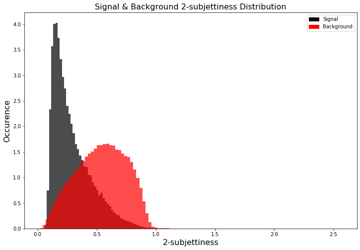

```python
plt.hist(higgs['t2'][:], 100, color = 'black', density=True, alpha=0.7)
plt.hist(qcd['t2'][:], 100, color = 'r', density=True, alpha=0.7)
plt.xlabel('2-subjettiness', fontsize=16)
plt.ylabel('Occurence', fontsize=16)
plt.title('Signal & Background 2-subjettiness Distribution', fontsize=16)
sig_patch = mpatches.Patch(color='black', label='Signal')
bcg_patch = mpatches.Patch(color='r', label='Background')
plt.legend(handles=[sig_patch, bcg_patch])
```

The graph above is the distributions of 2-subjettiness signal and background. Similar with 1-subjettiness, the background distribution becomes more like a poisson distribution, but it is slightly left skewed for 2-subjettiness.

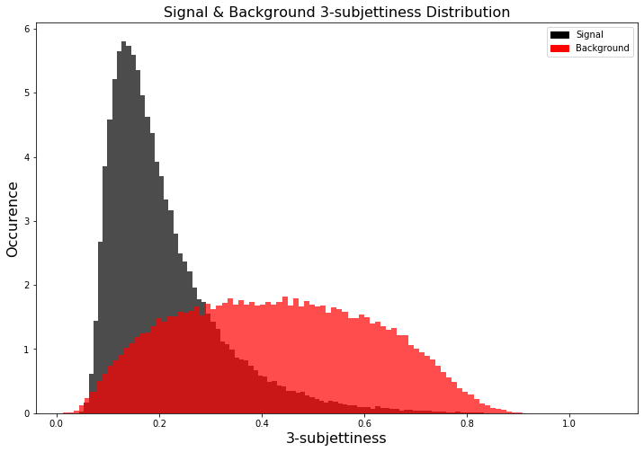

```python
plt.hist(higgs['t3'][:], 100, color = 'black', density=True, alpha=0.7)
plt.hist(qcd['t3'][:], 100, color = 'r', density=True, alpha=0.7)
plt.xlabel('3-subjettiness', fontsize=16)
plt.ylabel('Occurence', fontsize=16)
plt.title('Signal & Background 3-subjettiness Distribution', fontsize=16)
sig_patch = mpatches.Patch(color='black', label='Signal')
bcg_patch = mpatches.Patch(color='r', label='Background')
plt.legend(handles=[sig_patch, bcg_patch])
```

The graph above is the distributions of 3-subjettiness signal and background. We can see that the signal distribution still remains right-skewed and has a similar shape with 1-subjettiness and 2-subjettiness. However, the background distribution becomes a normal distribution with a mean about 0.43.

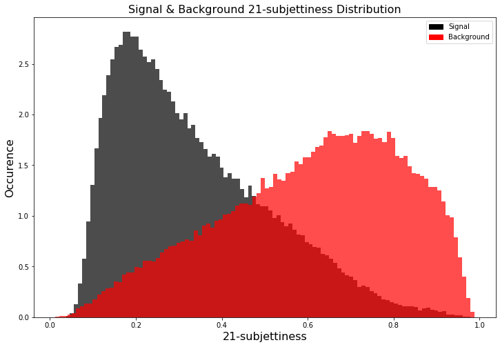

```python
plt.hist(higgs['t21'][:], 100, color = 'black', density=True, alpha=0.7)
plt.hist(qcd['t21'][:], 100, color = 'r', density=True, alpha=0.7)
plt.xlabel('21-subjettiness', fontsize=16)
plt.ylabel('Occurence', fontsize=16)
plt.title('Signal & Background 21-subjettiness Distribution', fontsize=16)
sig_patch = mpatches.Patch(color='black', label='Signal')
bcg_patch = mpatches.Patch(color='r', label='Background')
plt.legend(handles=[sig_patch, bcg_patch])
```

The above graph is the distributions of signal and background of 21-subjetiness. As we can see, the two distribution become poisson distributed and skew to the opposite directions with signal to the right and background to the left. The background data has a lot of noises around 0.7 and 0.8.

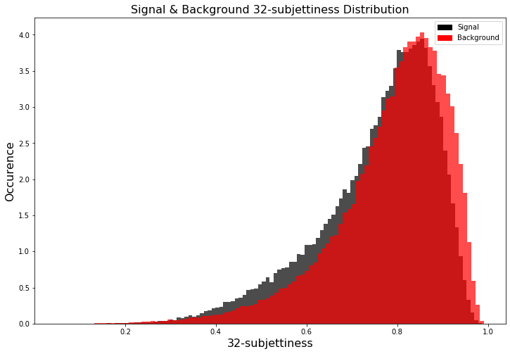

```python
plt.hist(higgs['t32'][:], 100, color = 'black', density=True, alpha=0.7)
plt.hist(qcd['t32'][:], 100, color = 'r', density=True, alpha=0.7)
plt.xlabel('32-subjettiness', fontsize=16)
plt.ylabel('Occurence', fontsize=16)
plt.title('Signal & Background 32-subjettiness Distribution', fontsize=16)
sig_patch = mpatches.Patch(color='black', label='Signal')
bcg_patch = mpatches.Patch(color='r', label='Background')
plt.legend(handles=[sig_patch, bcg_patch])
```

The above graph is the distributions of signal and background of 32-subjettiness. They are both left-skewed poisson distributions with similar mean around 0.85.

From the previous 5 graphs, we plotted the signal(black) and background(red) of 1-subjettiness to 3-subjettiness and 21-and 32-subjettiness. We can see that the data points distribution for signals for N-subjettiness did not change significantly and are all poisson-like distribution. But, for background, 1 to 3-subjettiness has a more normal distributed shape and becomes poisson distribution for 21- and 32-subjettiness. The most different plot is the distributions of signal and background of 32-subjettiness. The signal of 32-subjettiness is different from all other subjettiness with a left-skewed distribution.

Compared with all N-subjettiness, the 2-, 3-, and 21-subjettiness have a much greater discrimination power, where the 32-subjettiness has almost no difference between signal and background.

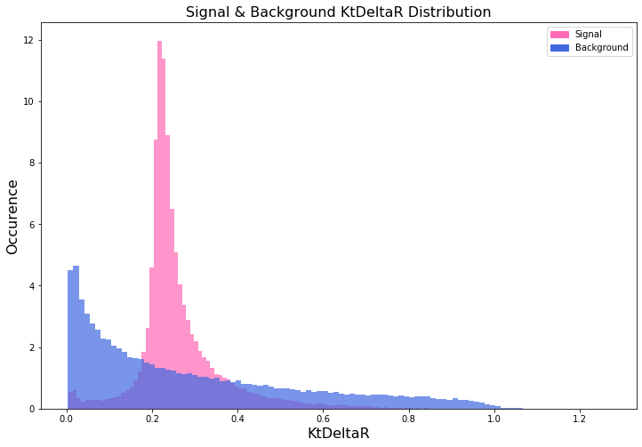

```python
plt.hist(higgs['KtDeltaR'][:], 100, color = 'hotpink', density=True, alpha=0.7)
plt.hist(qcd['KtDeltaR'][:], 100, color = 'royalblue', density=True, alpha=0.7)
plt.xlabel('KtDeltaR', fontsize=16)
plt.ylabel('Occurence', fontsize=16)
plt.title('Signal & Background KtDeltaR Distribution', fontsize=16)
sig_patch = mpatches.Patch(color='hotpink', label='Signal')
bcg_patch = mpatches.Patch(color='royalblue', label='Background')
plt.legend(handles=[sig_patch, bcg_patch])
```

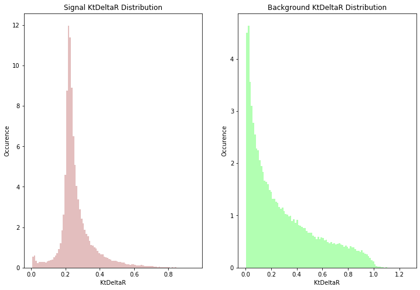

```python
fig, (ax1, ax2) = plt.subplots(1, 2)
ax1.hist(higgs['KtDeltaR'][:], 100, color = 'brown', density=True, alpha=0.3)
ax1.set_xlabel('KtDeltaR')
ax1.set_ylabel('Occurence')
ax1.set_title('Signal KtDeltaR Distribution')

ax2.hist(qcd['KtDeltaR'][:], 100, color = 'lime', density=True, alpha=0.3)
ax2.set_xlabel('KtDeltaR')
ax2.set_ylabel('Occurence')
ax2.set_title('Background KtDeltaR Distribution')
```

Correlations

We have discovered the discrimination power of all features and proved that it is not every feature that provides an ability to clearly distinguish between signal and background data. Now, we will be moving onto discovery of the correlation between different features, and we are doing this by plotting out the scatter plot with different features.

1. Transverse Momentum

```
(-0.18470539032085964, 0.0)
```

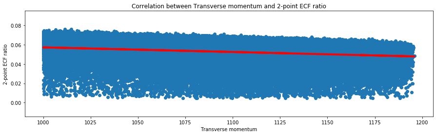

```python
plt.rcParams["figure.figsize"] = (15, 4)
fx, ax1 = plt.subplots(1, 1)
x = higgs['pt']
y = higgs['ee2']
ax1.scatter(x, y)
m1, b1 = np.polyfit(x, y, 1)
ax1.plot(x, m1*x + b1, color = 'r', linewidth = 4)
ax1.set_xlabel('Transverse momentum')
ax1.set_ylabel('2-point ECF ratio')
ax1.set_title('Correlation between Transverse momentum and 2-point ECF ratio')
print(stats.pearsonr(x, y))
```

```
(-0.2775395154320622, 0.0)
```

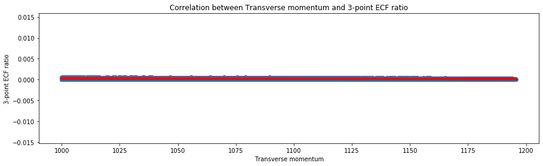

```python
plt.rcParams["figure.figsize"] = (15, 4)
fx, ax1 = plt.subplots(1, 1)
x = higgs['pt']
y = higgs['ee3']
ax1.scatter(x, y)
m1, b1 = np.polyfit(x, y, 1)
ax1.plot(x, m1*x + b1, color = 'r', linewidth = 4)
ax1.set_xlabel('Transverse momentum')
ax1.set_ylabel('3-point ECF ratio')
ax1.set_title('Correlation between Transverse momentum and 3-point ECF ratio')
print(stats.pearsonr(x, y))
```

1. Mass

```
(0.4821175323024456, 0.0)
```

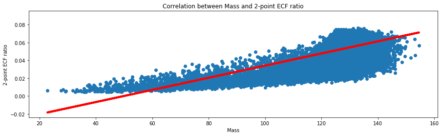

```python
plt.rcParams["figure.figsize"] = (15, 4)
fx, ax1 = plt.subplots(1, 1)
x = higgs['mass']
y = higgs['ee2']
ax1.scatter(x, y)
m1, b1 = np.polyfit(x, y, 1)
ax1.plot(x, m1*x + b1, color = 'r', linewidth = 4)
ax1.set_xlabel('Mass')
ax1.set_ylabel('2-point ECF ratio')
ax1.set_title('Correlation between Mass and 2-point ECF ratio')
print(stats.pearsonr(x, y))
```

```
(-0.6578842037352453, 0.0)
```

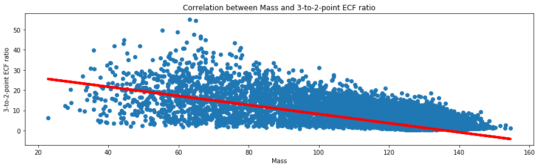

```python
plt.rcParams["figure.figsize"] = (15, 4)
fx, ax1 = plt.subplots(1, 1)
x = higgs['mass']
y = higgs['d2']
ax1.scatter(x, y)
m1, b1 = np.polyfit(x, y, 1)
ax1.plot(x, m1*x + b1, color = 'r', linewidth = 4)
ax1.set_xlabel('Mass')
ax1.set_ylabel('3-to-2-point ECF ratio')
ax1.set_title('Correlation between Mass and 3-to-2-point ECF ratio')
print(stats.pearsonr(x, y))
```

From the above graphs, we can see that the signal of mass has a positive correlation with the 2-point ECF ratio with correlation coefficient of 0.482. It also has a negative correlation with the 3-to-2 point ECF ratio.

1. 2-point ECF ratio

```
(-0.18470539032085964, 0.0)
(0.4821175323024456, 0.0)
(-0.7627073848844335, 0.0)
(-0.5622712757358258, 0.0)
```

[figure not shown]

```python
fx, (ax1, ax2, ax3, ax4) = plt.subplots(4, 1, sharey = True)
x = higgs['ee2']
y = higgs['pt']
ax1.scatter(x, y)
m1, b1 = np.polyfit(x, y, 1)
ax1.plot(x, m1*x + b1, color = 'r', linewidth = 4)
ax1.set_title('Correlation between 2-point ECF ratio and other features')
print(stats.pearsonr(x, y))

x2 = higgs['ee2']
y2 = higgs['mass']
ax2.scatter(x2, y2)
m2, b2 = np.polyfit(x2, y2, 1)
ax2.plot(x2, m2*x2 + b2, color = 'r', linewidth = 4)
print(stats.pearsonr(x2, y2))

x3 = higgs['ee2']
y3 = higgs['d2']
ax3.scatter(x3, y3)
m3, b3 = np.polyfit(x3, y3, 1)
ax3.plot(x3, m3*x3 + b3, color = 'r', linewidth = 4)
print(stats.pearsonr(x3, y3))

x4 = higgs['ee2']
y4 = higgs['angularity']
ax4.scatter(x4, y4)
m4, b4 = np.polyfit(x4, y4, 1)
ax4.plot(x4, m4*x4 + b4, color = 'r', linewidth = 4)
ax4.set_xlabel('2-point ECF ratio')
print(stats.pearsonr(x4, y4))
```

The above graghs plotted the correlations of signal of 2-point ECF ratio, we found three negative correlations with Transverse momentum, 3-to-2-point ECF ratio, angularity, and one positive correlation with mass.

Therefore, we can conclude that there exist correlations between different features in our datasets.